# Basic R concepts and commands, with WPA01 solutions (ds4psy)

Hansjörg Neth, SPDS, uni.kn

2019 04 28

# Introduction

All [ds4psy](http://rpository.com/ds4psy/) essentials so far:

| Nr. | Topic |
| --- | --- |
| 0. | [Syllabus](http://rpository.com/ds4psy/) |
| 1. | **Basic R concepts and commands** |

## Course coordinates

- PSY-15150, at the [University of Konstanz](https://www.uni-konstanz.de/) by [Hansjörg Neth](http://neth.de/) (h.neth@uni.kn, [SPDS](https://www.spds.uni-konstanz.de/), office D507).
- Summer 2019: Mondays, 15:15–16:45, D435.
- Links to current [course syllabus](http://rpository.com/ds4psy/) | [ZeUS](https://zeus.uni-konstanz.de:443/hioserver/pages/startFlow.xhtml?_flowId=detailView-flow&unitId=5101&periodId=179&navigationPosition=hisinoneLehrorganisation,examEventOverviewOwn) | [Ilias](https://ilias.uni-konstanz.de/ilias/goto_ilias_uni_crs_863036.html)

## Preliminaries

This session provides some background knowledge: First, some basics distinctions about data shapes and types (that apply to [R](http://www.r-project.org/), but also other programming languages) and then some basic concepts and commands of [R](http://www.r-project.org/).

It assumes the following:

1. **Software:** You have installed the software prerequisites mentioned in [Chapter 1.4](https://r4ds.had.co.nz/introduction.html#prerequisites) of [r4ds](https://r4ds.had.co.nz/). Specifically,
   1. A current version of [R](https://cloud.r-project.org);
   2. A current version of [RStudio](http://www.rstudio.com);
   3. The R packages of the [tidyverse](https://www.tidyverse.org).
2. **Readings:** You have read the following chapters of [r4ds](https://r4ds.had.co.nz/):
   1. *Introductions* ([Chapter 1](https://r4ds.had.co.nz/introduction.html) & [Chapter 2](https://r4ds.had.co.nz/explore-intro.html));
   2. *Workflow*: [basics (Chapter 4)](https://r4ds.had.co.nz/workflow-basics.html) & [scripts (Chapter 6)](https://r4ds.had.co.nz/workflow-scripts.html).

This implies that you understand and can do the following:

- Enter and run R commands at the prompt in the *Console* window of RStudio, and check their results;
- Use R as a calculator for simple arithmetic;
- Assign numeric values and characters to named objects;
- Call simple R functions on objects;
- Enter and run R scripts in the *Editor* window of RStudio.

## Preparations

Create an R script (`.R`) or an R-Markdown file (`.Rmd`) and load the R packages of the `tidyverse`. (Hint: Structure your script by inserting spaces, meaningful comments, and sections.)

```r
## R basics | ds4psy
## 2019 04 15
## ----------------------------

## Preparations: ----------

library(tidyverse)

## Topic: ----------

# ...

## End of file (eof). ----------
```

[figure not shown]

# Basic R Concepts and Commands

## Orientation

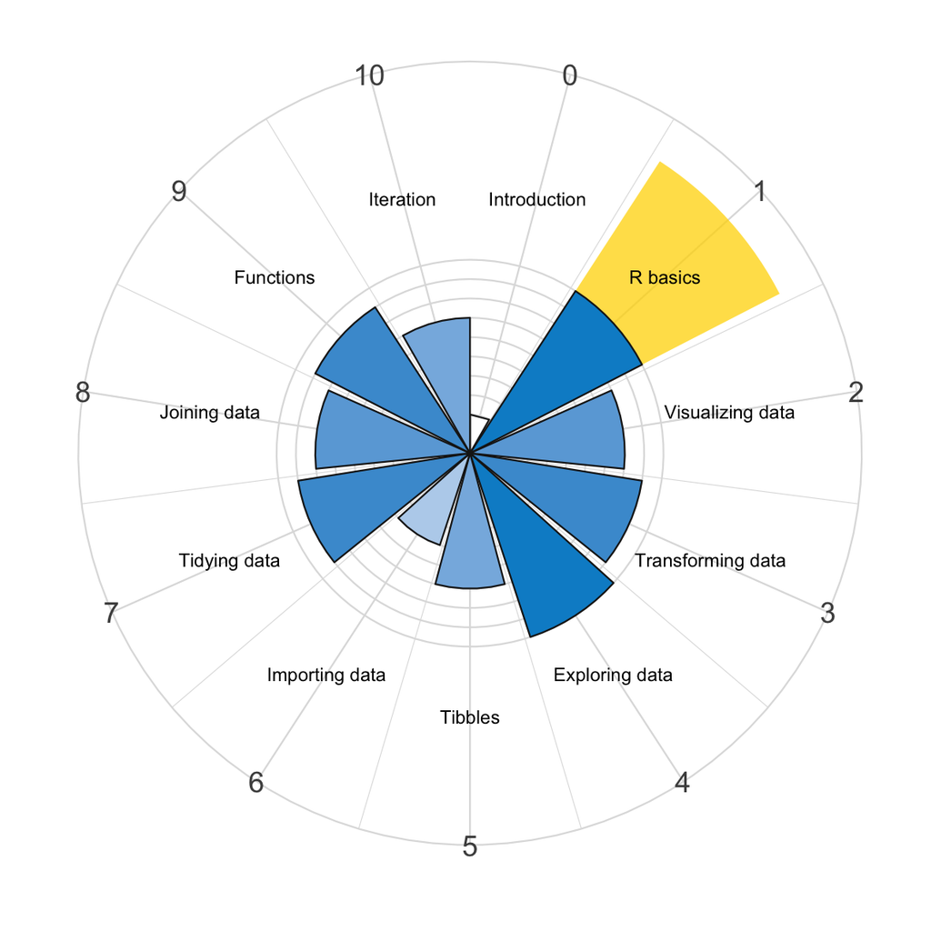

This chapter contains a brief introduction into basic concepts and commands when learning R (with examples, code outputs, exercises, and solutions).  
Strictly speaking, knowing some R is not a necessary precondition for reading and learning data science with our textbook ([r4ds](http://r4ds.had.co.nz)). However, it is certainly helpful – partly to appreciate how various `tidyverse` commands let you solve many problems in simpler and more transparent ways. Thus, please work through the examples, try to understand them, and then solve the corresponding exercises below.

After working through this chapter, you should be able to:

1. categorize R objects into data vs. functions;
2. disginuish between different shapes (e.g., scalars, vectors, rectangles) and types (e.g., numbers, text, logical values) of data;
3. create and change R objects by assignment;
4. apply arithmetic functions to objects;
5. select elements from vectors or rectangular data structures (by indexing).

## Data vs. functions

> “To understand computations in R, two slogans are helpful:  
> - Everything that exists is an object.  
> - Everything that happens is a function call.”  
> John Chambers

Using R and most other programming languages consists in

1. defining or loading *data* (material, values), and
2. evaluating *functions* (actions, verbs).

Confusingly, both data and functions in R are *objects* (stuff) and evaluating functions typically returns or creates new data objects (more stuff). To distinguish data from functions, think of data as *matter* (i.e., material or values that are being measured or manipulated) and functions as *procedures* (i.e., actions, operations, or verbs, that measure or manipulate data).

In the following, we will introduce some ways to describe data (by *shape* and *type*), learn to create new data objects (by assigning them with `<-`), and apply some pre-defined functions to these data objects.

### Data

In R, different data objects are characterized by their *shape* and by their *type*.

1. The most common *shapes* of data are:
   - *scalars*: atomic objects (i.e., a data point, with a length of 1);
   - *vectors*: a chain/sequence of objects of the same type (i.e., extending in 1 dimension: length);
   - *data frames*/*matrices*/*tibbles*: rectangular data (i.e., tables with 2 dimensions: rows vs. columns).
2. The most common *types* of data are:
   - *numeric* data (of type `double` or `integer`);
   - *text* data (of type `character`);
   - *logical* data (of type `logical`).

### Functions

In R, *functions* are ‘action objects’ that are applied to ‘data objects’ (a function’s so-called *arguments*, e.g., `a1` and `a2`) by specifying the function name and providing the arguments in round parentheses (i.e., `function(a1, a2)`). Think of functions as a process that takes some *input* (its arguments) and transforms it into *output* (the result returned by the function). An example of a function with 2 arguments is:

```r
sum(1, 2)
```

```
#> [1] 3
```

Here, the function `sum` is applied to 2 numeric arguments `1` and `2` (or a data structure that consists of 2 numeric scalars). Evaluating the expression `sum(1, 2)` returns a new data object `3`, which is the sum of the 2 original arguments.

### Practice

Evaluate the following expressions and describe what they are doing (in terms of applying functions to arguments to obtain new data):

```r
min(1, 2, -3, 4)
```

```
#> [1] -3
```

```r
paste0("ab", "cd")
```

```
#> [1] "abcd"
```

```r
substr("television", start = 5, stop = 10)
```

```
#> [1] "vision"
```

```r
substr("television", 20,  30)  # yields ""
```

```
#> [1] ""
```

### Defining objects

To define a new object `o` as `x`, use the *assignment* function `o <- x` and note that object names are case-sensitive (i.e., `a` and `A` are different object names).

For example, we can assign the output of a function to some object:

```r
s <- sum(1, 2)
s
```

```
#> [1] 3
```

Here, we created a new object (named `s`) and assigned the sum of 1 and 2 to it. As `s` is a numeric object (with the value 3), we can now apply any numeric function to it:

```r
s * 2
```

```
#> [1] 6
```

```r
s^2
```

```
#> [1] 9
```

Here is another example of creating 2 simple objects and applying simple arithmetic functions to them:

```r
o <- 10  # assign/set o to 10
O <-  5  # assign/set O to  5

# Computing with objects:
o * O
```

```
#> [1] 50
```

```r
o * 0
```

```
#> [1] 0
```

```r
o / O * 0
```

```
#> [1] 0
```

In R, objects can be described by their *length* and *type*.

- Objects with a length of 1 are called *scalars*, longer objects (i.e., `length(object) > 1`) are *vectors* or *lists*.
- The type of an object corresponds to the type of the object to which it has been assigned (e.g., `numeric`, `character`, or `logical`).

Hence, we can change an object’s type be re-assigning it:

```r
o <- 100
o
```

```
#> [1] 100
```

```r
# Check type:
is.numeric(o)
```

```
#> [1] TRUE
```

```r
is.character(o)
```

```
#> [1] FALSE
```

```r
is.logical(o)
```

```
#> [1] FALSE
```

```r
# Re-assigning o:
o <- paste0("ene", " ", "mene", " ", "mu")
o
```

```
#> [1] "ene mene mu"
```

```r
# Check type:
is.numeric(o)
```

```
#> [1] FALSE
```

```r
is.character(o)
```

```
#> [1] TRUE
```

```r
is.logical(o)
```

```
#> [1] FALSE
```

### Practice

```r
# Re-assign o:
o <- 1 > 2
o
```

```
#> [1] FALSE
```

```r
# Check type:
is.numeric(o)
```

```
#> [1] FALSE
```

```r
is.character(o)
```

```
#> [1] FALSE
```

```r
is.logical(o)
```

```
#> [1] TRUE
```

### Naming objects

Beware of the following characteristics and constraints:

- R is case sensitive (so `tea_pot`, `Tea_pot` and `tea_Pot` are different names that denote 3 different objects)
- No spaces inside variables (even though `tea pot` is possible)
- No special keywords that are reserved for R commands (`TRUE`, `FALSE`, `function`, `for`, `in`, `next`, `break`, `if`, `else`, `repeat`, `while`, `NULL`, `Inf`, `NaN`, `NA` and some variants like `NA_character`, `NA_integer`, …)

Recommendations:

- Aim for short and consistent names;
- Avoid dots and special characters in names;
- Use `snake_case` (with underscores) or `camelCase` (with capitalised first letters) for combined names.

## Scalars

### Defining scalars

We have learned that *scalars* are objects of length 1 (aka. *atomic* objects) and how to define objects by assigning names to them. So let’s define some scalar objects and then use some generic functions to check their length and type:

```r
a <- 1     # assign/set a to 1
a          # print a
```

```
#> [1] 1
```

```r
a + 2      # evaluate a + 2
```

```
#> [1] 3
```

```r
sum(a, 2)  # evaluate the function sum() with arguments a and 2
```

```
#> [1] 3
```

```r
b <- 2
b
```

```
#> [1] 2
```

```r
b * b
```

```
#> [1] 4
```

```r
prod(b, b)
```

```
#> [1] 4
```

```r
b ^ 2
```

```
#> [1] 4
```

```r
b^3
```

```
#> [1] 8
```

```r
c <- a + b  # assign c to the sum of a + b
c
```

```
#> [1] 3
```

```r
length(c)       # 1 could indicate a scalar OR the number of digits...
```

```
#> [1] 1
```

```r
length(1000)    # Check: also 1 (i.e., NOT number of digits)
```

```
#> [1] 1
```

```r
typeof(c)       # numbers are of type "integer" or "double"
```

```
#> [1] "double"
```

```r
typeof(3.14159) # decimal numbers are of type "double"
```

```
#> [1] "double"
```

```r
d <- "word" # note the quotes ("")
d
```

```
#> [1] "word"
```

```r
length(d)  # also a scalar
```

```
#> [1] 1
```

```r
typeof(d)  # but of type "character"
```

```
#> [1] "character"
```

```r
b
```

```
#> [1] 2
```

```r
a
```

```
#> [1] 1
```

```r
b > a          # result is neither number nor chacacter:
```

```
#> [1] TRUE
```

```r
typeof(a > b)  # yet another type: "logical"
```

```
#> [1] "logical"
```

```r
e <- b > a
e
```

```
#> [1] TRUE
```

```r
length(e)  # also a scalar
```

```
#> [1] 1
```

```r
typeof(e)  # of type "logical"
```

```
#> [1] "logical"
```

Thus, our exploration has shown that objects `a`, `b` and `c` are *numeric* objects (which can be of type *integer* or of type *double*), whereas `d` is a text object (of type *character*), and `e` is the result of a test that is either `TRUE` or `FALSE` (of type *logical*).

### Changing objects

To change an existing object, we need to re-assign it. Thus, changing an object works just like creating it:

```r
# Check values (defined above):
a
```

```
#> [1] 1
```

```r
b
```

```
#> [1] 2
```

```r
a/b
```

```
#> [1] 0.5
```

```r
a <- 100  # changes a
a         # a has changed
```

```
#> [1] 100
```

```r
a/b       # a/b changes when a has been changed
```

```
#> [1] 50
```

```r
b <- 200  # changes b
b         # b has changed
```

```
#> [1] 200
```

```r
a/b       # a/b changes when b has been changed
```

```
#> [1] 0.5
```

```r
d
```

```
#> [1] "word"
```

```r
d <- "weird"  # changes d
d
```

```
#> [1] "weird"
```

This implies that the *order* of evaluations matters: The same object (e.g., `a` or `a/b`) has different contents at different locations and at different times. (Note that the line numbers to the left of your editor window mark locations and that R scripts are typically evaluated in a top-down fashion.)

### Applying functions to scalars

We have evaluated some simple functions to data arguments above, but not all functions can be applied to all data. Importantly, most functions require specific types of arguments to work (i.e., the actual argument types must match the required argument types of the function).

When viewing this requirement from the perspective of existing objects, the type of an object determines which functions can be applied to it:

```r
# Start with numeric objects:
a
```

```
#> [1] 100
```

```r
typeof(a)  # a generic function (working with all object types)
```

```
#> [1] "double"
```

```r
length(a)  # a scalar
```

```
#> [1] 1
```

```r
a + b
```

```
#> [1] 300
```

```r
sum(a, b)  # an arithmetic function (requiring numeric object types)
```

```
#> [1] 300
```

```r
# Start with character objects:
d
```

```
#> [1] "weird"
```

```r
typeof(d)
```

```
#> [1] "character"
```

```r
length(d) # a scalar
```

```
#> [1] 1
```

```r
nchar(d)  # the "length" of a character object
```

```
#> [1] 5
```

```r
# Start with logical objects:
e
```

```
#> [1] TRUE
```

```r
typeof(e)
```

```
#> [1] "logical"
```

```r
!e          # negation (reverses logical value)
```

```
#> [1] FALSE
```

```r
!!e
```

```
#> [1] TRUE
```

```r
isTRUE(e)   # tests a logcial expression
```

```
#> [1] TRUE
```

```r
isTRUE(!e)
```

```
#> [1] FALSE
```

```r
e == !!e    # tests equality
```

```
#> [1] TRUE
```

In case of a mismatch between function and object types, an error may occur:

```r
# Evaluate the following (and explain the error):
a + d
sum(a, d)
d^2
```

### Arithmetic functions

For numeric objects, we can compute new numeric values by applying arithmetic functions:

```r
## (A) Arithmetic operators: ----
+ 2    # keeping sign
```

```
#> [1] 2
```

```r
- 3    # reversing sign
```

```
#> [1] -3
```

```r
1 + 2  # addition
```

```
#> [1] 3
```

```r
3 - 1  # subtraction
```

```
#> [1] 2
```

```r
2 * 3  # multiplication
```

```
#> [1] 6
```

```r
5 / 2  # division
```

```
#> [1] 2.5
```

```r
5 %/% 2  # integer division
```

```
#> [1] 2
```

```r
5 %% 2   # remainder of integer division (x mod y)
```

```
#> [1] 1
```

```r
## (B) Operator precedence: ----
1 / 2 * 3   # left to right
```

```
#> [1] 1.5
```

```r
1 + 2 * 3   # precedence: */ before +-
```

```
#> [1] 7
```

```r
(1 + 2) * 3 # changing order by parentheses
```

```
#> [1] 9
```

```r
# "BEDMAS" order:
# - brackets (),
# - exponents ^,
# - division / and multiplication *,
# - addition + and subtraction -
# See
# ?Syntax
# for complete rules.

2 * 2 * 2
```

```
#> [1] 8
```

```r
2^3
```

```
#> [1] 8
```

```r
## (C) Arithmetic with scalar objects: ----
x <- 2
y <- 3

+ x     # keeping sign
```

```
#> [1] 2
```

```r
- y     # reversing sign
```

```
#> [1] -3
```

```r
x + y   # addition
```

```
#> [1] 5
```

```r
x - y   # subtraction
```

```
#> [1] -1
```

```r
x * y   # multiplication
```

```
#> [1] 6
```

```r
x / y   # division
```

```
#> [1] 0.6666667
```

```r
x ^ y   # exponentiation
```

```
#> [1] 8
```

```r
x %/% y # integer division
```

```
#> [1] 0
```

```r
x %% y  # remainder of integer division (x mod y)
```

```
#> [1] 2
```

The same arithmetic operators also work with numeric *vectors* (see **Exercise 3** below). (See `?Arithmetic` for help on arithmetic operators and `?Syntax` for a full list of precedence groups.)

### Logical values and operators

By comparing numbers and using logical operators, we can obtain logical values (i.e., scalars of type *logical* that are either `TRUE` or `FALSE`) by conducting tests on numeric values:

```r
## Logical comparisons:
2 > 1   # larger than
```

```
#> [1] TRUE
```

```r
2 >= 2  # larger than or equal to
```

```
#> [1] TRUE
```

```r
2 < 1   # smaller than
```

```
#> [1] FALSE
```

```r
2 <= 1  # smaller than or equal to
```

```
#> [1] FALSE
```

```r
1 == 1  # == ... equality
```

```
#> [1] TRUE
```

```r
1 != 1  # != ... inequality
```

```
#> [1] FALSE
```

```r
## Logical operators:
(2 > 1) & (1 > 2)   # & ... logical AND
```

```
#> [1] FALSE
```

```r
(2 < 1) | (1 < 2)   # | ... logical OR
```

```
#> [1] TRUE
```

```r
(1 < 1) | !(1 < 1)  # ! ... logical negation
```

```
#> [1] TRUE
```

## Vectors

*Vectors* are the most common and most important data type in R. A *vector* is a sequence of objects of the same type.

### Creating vectors

To create a new vector, we can *combine* several objects of the *same type* with the `c()` function, separating vector elements by commas:

```r
# Creating vectors:
c(1, 2, 3)
```

```
#> [1] 1 2 3
```

```r
c(a, b)
```

```
#> [1] 100 200
```

```r
v <- c(a, b, c)
v
```

```
#> [1] 100 200   3
```

```r
v <- c(c, c, c)  # vectors can have repeated elements
v
```

```
#> [1] 3 3 3
```

```r
v <- c(a, b, v)  # Note that vectors can contain vectors, ...
v
```

```
#> [1] 100 200   3   3   3
```

```r
v <- c(v, v)     # but the result is only 1 vector, not 2.
v
```

```
#>  [1] 100 200   3   3   3 100 200   3   3   3
```

```r
# Character vectors:
w <- c("one", "two", "three")
w
```

```
#> [1] "one"   "two"   "three"
```

```r
w <- c(w, "four", "5", "many")
w
```

```
#> [1] "one"   "two"   "three" "four"  "5"     "many"
```

```r
# Applying functions to vectors:
length(v)
```

```
#> [1] 10
```

```r
typeof(v)
```

```
#> [1] "double"
```

```r
sum(v)
```

```
#> [1] 618
```

```r
length(w)
```

```
#> [1] 6
```

```r
typeof(w)
```

```
#> [1] "character"
```

```r
# sum(w)  # would yield an error

# Combining different types:
x <- c(1, "two", 3)
x
```

```
#> [1] "1"   "two" "3"
```

```r
typeof(x)  # converted 1 to "1" (as all vector elements must be of the same type)
```

```
#> [1] "character"
```

### Scalar objects are vectors

Actually, R has no dedicated type of scalar objects. Instead, individual numbers (of type integer or double) or text strings (of type character) are actually vectors of length 1:

```r
a
```

```
#> [1] 100
```

```r
is.vector(a)
```

```
#> [1] TRUE
```

```r
length(a)
```

```
#> [1] 1
```

```r
d
```

```
#> [1] "weird"
```

```r
is.vector(d)
```

```
#> [1] TRUE
```

```r
length(d)
```

```
#> [1] 1
```

```r
e
```

```
#> [1] TRUE
```

```r
is.vector(e)
```

```
#> [1] TRUE
```

```r
length(e)
```

```
#> [1] 1
```

### Special vector creation functions

For creating vectors with more than just a few elements (i.e., with larger `length` values), the `c` function becomes impractical. Some useful functions and shortcuts are:

```r
# Sequences (with sep):
s1 <- seq(0, 100, 1)  # is short for:
s2 <- seq(from = 0, to = 100, by = 1)
s2
```

```
#>  [1]  0  1  2  3  4  5  6  7  8  9 10 11 12 13 14 15 16 17 18 19 20 21 22
#> [24] 23 24 25 26 27 28 29 30 31 32 33 34 35 36 37 38 39 40 41 42 43 44 45
#> [47] 46 47 48 49 50 51 52 53 54 55 56 57 58 59 60 61 62 63 64 65 66 67 68
#> [70] 69 70 71 72 73 74
#>  [ reached getOption("max.print") -- omitted 26 entries ]
```

```r
all.equal(s1, s2)
```

```
#> [1] TRUE
```

```r
# Shorter version (with by = 1):
s3 <- 0:100
all.equal(s1, s3)
```

```
#> [1] TRUE
```

```r
# But seq allows different step sizes:
s4 <- seq(0, 100, by = 25)
s4
```

```
#> [1]   0  25  50  75 100
```

```r
# Replicating (with rep):
s5 <- rep(c(0, 1), 3)  # is short for:
s5 <- rep(x = c(0, 1), times = 3)
s5
```

```
#> [1] 0 1 0 1 0 1
```

```r
# Sampling vector elements (with sample):
sample(1:3, 10, replace = TRUE)
```

```
#>  [1] 1 3 2 2 1 1 3 1 1 1
```

```r
# Note:
# sample(1:3, 10, replace = FALSE)  # would yield an error

coin <- c("H", "T")    # 2 events: Heads or Tails
sample(coin, 5, TRUE)  # is short for:
```

```
#> [1] "T" "H" "T" "T" "H"
```

```r
sample(x = coin, size = 5, replace = TRUE)     # flip coin 5 times
```

```
#> [1] "T" "T" "H" "H" "H"
```

```r
sample(x = coin, size = 1000, replace = TRUE)  # flip coin 1000 times
```

```
#>  [1] "T" "H" "T" "H" "T" "H" "H" "T" "T" "T" "T" "H" "H" "T" "T" "T" "T"
#> [18] "T" "T" "H" "H" "T" "H" "H" "H" "H" "H" "H" "T" "T" "H" "H" "T" "H"
#> [35] "T" "H" "H" "H" "H" "T" "H" "H" "T" "H" "H" "T" "H" "H" "H" "T" "H"
#> [52] "H" "H" "T" "T" "H" "T" "T" "T" "H" "H" "T" "T" "T" "H" "H" "H" "H"
#> [69] "H" "H" "T" "H" "H" "T" "H"
#>  [ reached getOption("max.print") -- omitted 925 entries ]
```

### Indexing vectors

We often store a lot of values in vectors (e.g., the age of 1000 participants), but only need some of them for answering specific questions (e.g., what is the average age of all male participants?). To *select* only a subset of elements from a vector `v` we can specify the condition or criterion for our selection in (square) brackets `v[...]`.

```r
# Example 1: Indexing numeric vectors
x <- 1:10
x
```

```
#>  [1]  1  2  3  4  5  6  7  8  9 10
```

```r
crit <- x > 5  # Condition: Which values of x are larger than 5?
crit
```

```
#>  [1] FALSE FALSE FALSE FALSE FALSE  TRUE  TRUE  TRUE  TRUE  TRUE
```

```r
x[crit]   # using crit to select values of x (for which crit is TRUE)
```

```
#> [1]  6  7  8  9 10
```

```r
x[x > 5]  # all in 1 step
```

```
#> [1]  6  7  8  9 10
```

```r
## Example 2: Indexing character vectors
spices <- c("salt", "pepper", "cinnamon", "lemongrass", "mint", "mustard", "wasabi")

spices[nchar(spices) == 4]           # spices with exactly 4 letters
```

```
#> [1] "salt" "mint"
```

```r
spices[substr(spices, 2, 2) == "i"]  # spices with an "i" at 2nd position
```

```
#> [1] "cinnamon" "mint"
```

## Rectangular data

Vectors are 1-dimensional objects (i.e., have a length, but no width). By combining several vectors, we get a *rectangular* data structure.

### Matrices

When a rectangle of data contains data of the same type in all cells, we get a *matrix* of data:

```r
x <- 1:3
y <- 4:6
z <- 7:9

# Combining vectors (of the same length): ----
r1 <- rbind(x, y, z)  # combine as rows
r1
```

```
#>   [,1] [,2] [,3]
#> x    1    2    3
#> y    4    5    6
#> z    7    8    9
```

```r
r2 <- cbind(x, y, z)  # combine as columns
r2
```

```
#>      x y z
#> [1,] 1 4 7
#> [2,] 2 5 8
#> [3,] 3 6 9
```

```r
# Putting a vector into a rectangular matrix:
r3 <- matrix(data = 1:20, nrow = 5, ncol = 4, byrow = TRUE)
r3
```

```
#>      [,1] [,2] [,3] [,4]
#> [1,]    1    2    3    4
#> [2,]    5    6    7    8
#> [3,]    9   10   11   12
#> [4,]   13   14   15   16
#> [5,]   17   18   19   20
```

```r
r4 <- matrix(data = 1:20, nrow = 5, ncol = 4, byrow = FALSE)
r4
```

```
#>      [,1] [,2] [,3] [,4]
#> [1,]    1    6   11   16
#> [2,]    2    7   12   17
#> [3,]    3    8   13   18
#> [4,]    4    9   14   19
#> [5,]    5   10   15   20
```

```r
# Selecting cells, rows, or columns of matrices: ----
r1[2, 3]  # in r1: select row 2, column 3
```

```
#> y
#> 6
```

```r
r2[3, 1]  # in r2: select row 3, column 1
```

```
#> x
#> 3
```

```r
r1[2,  ]  # in r1: select row 2, all columns
```

```
#> [1] 4 5 6
```

```r
r2[ , 1]  # in r1: select column 1, all rows
```

```
#> [1] 1 2 3
```

```r
r3
```

```
#>      [,1] [,2] [,3] [,4]
#> [1,]    1    2    3    4
#> [2,]    5    6    7    8
#> [3,]    9   10   11   12
#> [4,]   13   14   15   16
#> [5,]   17   18   19   20
```

```r
r3[2, 3:4] # in r3: select row 2, columns 3 to 4
```

```
#> [1] 7 8
```

```r
r3[3:5, 2] # in r3: select rows 3 to 5, column 2
```

```
#> [1] 10 14 18
```

```r
r4[]  # in r4: select all rows and all columns (i.e., all of r4)
```

```
#>      [,1] [,2] [,3] [,4]
#> [1,]    1    6   11   16
#> [2,]    2    7   12   17
#> [3,]    3    8   13   18
#> [4,]    4    9   14   19
#> [5,]    5   10   15   20
```

```r
# Applying functions to matrices: ----
is.matrix(r1)
```

```
#> [1] TRUE
```

```r
typeof(r2)
```

```
#> [1] "integer"
```

```r
dim(r1)   # dimensions of r2: 3 rows and 3 columns
```

```
#> [1] 3 3
```

```r
nrow(r2)  # number of rows of r2
```

```
#> [1] 3
```

```r
ncol(r3)  # number of columns of r3
```

```
#> [1] 4
```

```r
sum(r1)
```

```
#> [1] 45
```

```r
max(r2)
```

```
#> [1] 9
```

```r
mean(r3)
```

```
#> [1] 10.5
```

```r
colSums(r3)  # column sums of r3
```

```
#> [1] 45 50 55 60
```

```r
rowSums(r4)  # row sums of r4
```

```
#> [1] 34 38 42 46 50
```

```r
r4 > 10  # returns a matrix of logical values
```

```
#>       [,1]  [,2] [,3] [,4]
#> [1,] FALSE FALSE TRUE TRUE
#> [2,] FALSE FALSE TRUE TRUE
#> [3,] FALSE FALSE TRUE TRUE
#> [4,] FALSE FALSE TRUE TRUE
#> [5,] FALSE FALSE TRUE TRUE
```

```r
typeof(r4 > 10)
```

```
#> [1] "logical"
```

```r
r4[r4 > 10]  # indexing of matrices
```

```
#>  [1] 11 12 13 14 15 16 17 18 19 20
```

### Data frames / tibbles

As matrices contain data of only 1 type (e.g., all cells are all numeric, character, or logical data), we need another data structure for more diverse and interesting datasets. The most common rectangular data structure in R is a *data frame* (or *tibble*, which is a simpler version of a data frame used in the `tidyverse`).

Let’s create a data frame from vectors:

```r
# Create some vectors (of different types, but same length): -----
name <- c("Adam", "Bertha", "Cecily", "Dora", "Eve", "Nero", "Zeno")
gender <- c("male", "female", "female", "female", "female", "male", "male")
age <- c(21, 23, 22, 19, 21, 18, 24)
height <- c(165, 170, 168, 172, 158, 185, 182)

# Combine 4 vectors (of equal length) into a data frame:
df <- data.frame(name, gender, age, height)
df    # Note: Vectors are the columns of the data frame!
```

```
#>     name gender age height
#> 1   Adam   male  21    165
#> 2 Bertha female  23    170
#> 3 Cecily female  22    168
#> 4   Dora female  19    172
#> 5    Eve female  21    158
#> 6   Nero   male  18    185
#> 7   Zeno   male  24    182
```

```r
is.matrix(df)
```

```
#> [1] FALSE
```

```r
is.data.frame(df)
```

```
#> [1] TRUE
```

```r
dim(df)  # 7 cases (rows) x 4 variables (columns)
```

```
#> [1] 7 4
```

```r
# Note that
# sum(df)  # would yield an error
```

We can easily turn any data frame into a tibble (by using the `as_tibble` command of the `tidyverse` package `tibble`):

```r
tb <- tibble::as_tibble(df)
dim(tb)  # 7 cases (rows) x 4 variables (columns), as df
```

```
#> [1] 7 4
```

We will learn more about tibbles later. For now, a tibble is just a simpler and more convenient type of data frame. For instance, printing a tibble always shows its dimensions (as in `dim(tb)`) and the type of each variable (column):

```r
tb
```

```
#> # A tibble: 7 x 4
#>   name   gender   age height
#>   <fct>  <fct>  <dbl>  <dbl>
#> 1 Adam   male      21    165
#> 2 Bertha female    23    170
#> 3 Cecily female    22    168
#> 4 Dora   female    19    172
#> 5 Eve    female    21    158
#> 6 Nero   male      18    185
#> 7 Zeno   male      24    182
```

### Working with data frames / tibbles

Selecting cells, cases (rows), or variables (columns) of a data frame:

```r
# Selecting cells, rows or columns: -----
df[5, 3]  # cell in row 5, column 3: 21 (age of Eve)
```

```
#> [1] 21
```

```r
df[6, ]   # row 6: Nero etc.
```

```
#>   name gender age height
#> 6 Nero   male  18    185
```

```r
df[ , 4]  # column 4: height values
```

```
#> [1] 165 170 168 172 158 185 182
```

```r
names(df)    # yields the names of all variables (columns), as a vector
```

```
#> [1] "name"   "gender" "age"    "height"
```

```r
names(df)[4] # the name of the 4th variable
```

```
#> [1] "height"
```

```r
# Selecting variables (columns) by their name (with $ operator):
df$gender  # returns gender vector
```

```
#> [1] male   female female female female male   male
#> Levels: female male
```

```r
df$age     # returns age vector
```

```
#> [1] 21 23 22 19 21 18 24
```

Applying functions to variables (columns):

```r
# Applying functions to columns of df:
df$gender == "male"
```

```
#> [1]  TRUE FALSE FALSE FALSE FALSE  TRUE  TRUE
```

```r
sum(df$gender == "male")
```

```
#> [1] 3
```

```r
df$age < 21
```

```
#> [1] FALSE FALSE FALSE  TRUE FALSE  TRUE FALSE
```

```r
df$age[df$age < 21]
```

```
#> [1] 19 18
```

```r
df$name[df$age < 21]
```

```
#> [1] Dora Nero
#> Levels: Adam Bertha Cecily Dora Eve Nero Zeno
```

```r
mean(df$height)
```

```
#> [1] 171.4286
```

```r
df$height < 170
```

```
#> [1]  TRUE FALSE  TRUE FALSE  TRUE FALSE FALSE
```

```r
df$gender[df$height < 170]
```

```
#> [1] male   female female
#> Levels: female male
```

Creating new variables: To create a new variable, we simply assign something to a new variable name.

```r
df
```

```
#>     name gender age height
#> 1   Adam   male  21    165
#> 2 Bertha female  23    170
#> 3 Cecily female  22    168
#> 4   Dora female  19    172
#> 5    Eve female  21    158
#> 6   Nero   male  18    185
#> 7   Zeno   male  24    182
```

```r
dim(df)  # 7 cases (rows) x 4 variables (columns)
```

```
#> [1] 7 4
```

```r
# Create a new variable:
df$may_drink <- NA  # initialize a new variable (column) with unknown (NA) values
df # => may_drink was added as a new column to df, all instances are NA
```

```
#>     name gender age height may_drink
#> 1   Adam   male  21    165        NA
#> 2 Bertha female  23    170        NA
#> 3 Cecily female  22    168        NA
#> 4   Dora female  19    172        NA
#> 5    Eve female  21    158        NA
#> 6   Nero   male  18    185        NA
#> 7   Zeno   male  24    182        NA
```

```r
# Assign values:  A person may drink (alcohol, in the US),
df$may_drink <- (df$age >= 21)  # if s/he is 21 (or older)
df
```

```
#>     name gender age height may_drink
#> 1   Adam   male  21    165      TRUE
#> 2 Bertha female  23    170      TRUE
#> 3 Cecily female  22    168      TRUE
#> 4   Dora female  19    172     FALSE
#> 5    Eve female  21    158      TRUE
#> 6   Nero   male  18    185     FALSE
#> 7   Zeno   male  24    182      TRUE
```

```r
# Note:
# - we did not use an if-then statement
# - we did not specify separate TRUE vs. FALSE cases
# - we can assign and set new variables in 1 step:

df$is_female <- (df$gender == "female")
df
```

```
#>     name gender age height may_drink is_female
#> 1   Adam   male  21    165      TRUE     FALSE
#> 2 Bertha female  23    170      TRUE      TRUE
#> 3 Cecily female  22    168      TRUE      TRUE
#> 4   Dora female  19    172     FALSE      TRUE
#> 5    Eve female  21    158      TRUE      TRUE
#> 6   Nero   male  18    185     FALSE     FALSE
#> 7   Zeno   male  24    182      TRUE     FALSE
```

### Changing variable types

When working with vectors or rectangles of data, we often need or want to convert the type of a variable into another one. To convert a variable, we simply assign it to itself (so that all its values will be preserved) and wrap a type conversion function (`as.character`, `as.integer`, `as.numeric` or `factor`) around it:

```r
levels(df$gender)  # currently a so-called "factor" variable
```

```
#> [1] "female" "male"
```

```r
typeof(df$gender)  # of type "integer"
```

```
#> [1] "integer"
```

```r
df$gender <- as.character(df$gender)  # convert into a character variable
typeof(df$gender)  # now of type "character"
```

```
#> [1] "character"
```

```r
df$gender <- as.factor(df$gender)  # convert from "character" into a "factor"
df$gender
```

```
#> [1] male   female female female female male   male
#> Levels: female male
```

```r
typeof(df$gender)  # again of type "integer"
```

```
#> [1] "integer"
```

```r
typeof(df$age)  # numeric "double"
```

```
#> [1] "double"
```

```r
df$age <- as.integer(df$age)  # convert from "double" to "integer"
typeof(df$age)  # "integer"
```

```
#> [1] "integer"
```

```r
df$age <- as.numeric(df$age)  # convert from "integer" to numeric "double"
typeof(df$age)  # numeric "double"
```

```
#> [1] "double"
```

### Importing data

In most cases, we don’t generate the data that we analyze, but obtain it from somewhere (e.g., online). For instance, Woodworth et al. (2018, DOI: https://doi.org/10.5334/jopd.35) examined the long-term effectiveness of different web-based positive psychology interventions (see [this link](https://openpsychologydata.metajnl.com/articles/10.5334/jopd.35/) for details). We can load their participant data into R with the following command (from the package `readr`, which is part of the `tidyverse`):

```r
p_info <- readr::read_csv(file = "http://rpository.com/ds4psy/data/posPsy_participants.csv")

dim(p_info)      # 295 rows, 6 columns
```

```
#> [1] 295   6
```

```r
p_info           # prints a summary of the table/tibble
```

```
#> # A tibble: 295 x 6
#>       id intervention   sex   age  educ income
#>    <dbl>        <dbl> <dbl> <dbl> <dbl>  <dbl>
#>  1     1            4     2    35     5      3
#>  2     2            1     1    59     1      1
#>  3     3            4     1    51     4      3
#>  4     4            3     1    50     5      2
#>  5     5            2     2    58     5      2
#>  6     6            1     1    31     5      1
#>  7     7            3     1    44     5      2
#>  8     8            2     1    57     4      2
#>  9     9            1     1    36     4      3
#> 10    10            2     1    45     4      3
#> # … with 285 more rows
```

```r
glimpse(p_info)  # shows the first values for 6 variables (columns)
```

```
#> Observations: 295
#> Variables: 6
#> $ id           <dbl> 1, 2, 3, 4, 5, 6, 7, 8, 9, 10, 11, 12, 13, 14, 15, …
#> $ intervention <dbl> 4, 1, 4, 3, 2, 1, 3, 2, 1, 2, 2, 2, 4, 4, 4, 4, 3, …
#> $ sex          <dbl> 2, 1, 1, 1, 2, 1, 1, 1, 1, 1, 1, 1, 1, 1, 2, 1, 1, …
#> $ age          <dbl> 35, 59, 51, 50, 58, 31, 44, 57, 36, 45, 56, 46, 34,…
#> $ educ         <dbl> 5, 1, 4, 5, 5, 5, 5, 4, 4, 4, 5, 4, 5, 1, 2, 1, 4, …
#> $ income       <dbl> 3, 1, 3, 2, 2, 1, 2, 2, 3, 3, 1, 3, 3, 2, 2, 1, 2, …
```

When analyzing a data file from a remote source, it’s crucial to also obtain a description of the variables and values contained in the file (often called a *Codebook*). For the file `posPsy_participants.csv` this could look like:

`posPsy_participants.csv` contains *demographic information* on participants:

- `id`: participant ID
- `intervention`: 3 positive psychology interventions, plus 1 control condition:
  - 1 = “Using Signature Strengths”,
  - 2 = “Three Good Things”,
  - 3 = “Gratitude Visit”,
  - 4 = “Recording early memories” (control condition).
- `sex`:
  - 1 = female,
  - 2 = male.
- `age`: participant’s age (in years).
- `educ`: level of education:
  - 1 = Less than Year 12,
  - 2 = Year 12,
  - 3 = Vocational training,
  - 4 = Bachelor’s degree,
  - 5 = Postgraduate degree.
- `income`:
  - 1 = below average,
  - 2 = average,
  - 3 = above average.

We will examine these variables in **Exercise 6** (below).

# Exercises (WPA01) with Solutions

[figure not shown]

The following exercises are your first weekly programming assignment (**WPA01**).  
Please submit your solutions (as an `.R` or `.Rmd` script that is named `LastFirstname_WPA01.R`) into the corresponding folder on [Ilias](https://ilias.uni-konstanz.de/ilias/goto_ilias_uni_crs_863036.html) by **Thursday, May 2nd, 2019**.

## Exercise 1

This first exercise assumes that your current working environment contains the following objects and assignments:

```r
a <- 100
b <- 200
d <- "weird"
e <- TRUE
o <- FALSE
O <- 5
```

Evaluate and explain the following results (and correct any errors that may occur):

```r
# Note: The following assume the object definitions from above.
a
b
b <- a + a
a + a == b
!!a

sqrt(2)  # see ?sqrt
sqrt(2)^2
sqrt(2)^2 == 2  # Why FALSE?
# Hint: Compute the difference sqrt(2)^2 - 2
sqrt(2)^2 - 2   # is not 0

o / O / 0   # (using o and O from above)
0 / (o * O)
0 / (o * 0)

a + b + C   # are all objects defined?

sum(a, b) - sum(a + b)

b:a  # divide b by a
length(b:a)

i <- i + 1  # increment i by 1

nchar(d) - length(d)

e
e + e + !!e

e <- stuff
paste(d, e)  # paste "adds" 2 character objects
```

## Exercise 2

With only a little knowledge of R you can perform quite fancy financial arithmetic. Assume that you have won an amount of EUR 1000 and are considering to deposit this amount into a new bank account that offers an annual interest rate of 0.1%.

1. How much would your account be worth after waiting for 2 full years?
2. What would be the time value of your money after 2 full years if the annual inflation rate is 2%?
3. What would be the results to 1. and 2. if you waited for 100 years?

Answer these questions by defining well-named objects and performing simple arithmetic computations on them.

```r
# Definitions:
savings_0 <- 1000    # initial savings (year 0)
interest  <- .1/100  # interest rate (annual)
inflation <- 2/100   # inflation rate (annual)
n_years <- 2

## 1. Savings with interest: -----

# In 2 steps:
savings_1 <- savings_0 + (savings_0 * interest)  # after 1 year
savings_1
```

```
#> [1] 1001
```

```r
savings_2 <- savings_1 + (savings_1 * interest)  # after 2 years
savings_2
```

```
#> [1] 1002.001
```

```r
# Both in 1 step:
savings_0 * (1 + interest)^n_years
```

```
#> [1] 1002.001
```

```r
# 2. Also accounting for inflation: -----
savings_0 * (1 + interest - inflation)^n_years
```

```
#> [1] 962.361
```

```r
# 3. Different numbers of years:
n_years <- 100

# Use same formulas:
savings_0 * (1 + interest)^n_years  # interest only
```

```
#> [1] 1105.116
```

```r
savings_0 * (1 + interest - inflation)^n_years  # interest + inflation
```

```
#> [1] 146.8591
```

## Exercise 3

When introducing arithmetic functions above, we showed that they can be used with numeric scalars (i.e., numeric objects with a length of 1).

1. Demonstrate that the same arithmetic functions also work with 2 numeric vectors `x` and `y` (of the same length).
2. What happens when `x` and `y` have different lengths?

```r
## 1. Arithmetic with vectors of the same length:
x <- c(2, 4, 6)
y <- c(1, 2, 3)

+ x     # keeping sign
```

```
#> [1] 2 4 6
```

```r
- y     # reversing sign
```

```
#> [1] -1 -2 -3
```

```r
x + y   # addition
```

```
#> [1] 3 6 9
```

```r
x - y   # subtraction
```

```
#> [1] 1 2 3
```

```r
x * y   # multiplication
```

```
#> [1]  2  8 18
```

```r
x / y   # division
```

```
#> [1] 2 2 2
```

```r
x ^ y   # exponentiation
```

```
#> [1]   2  16 216
```

```r
x %/% y # integer division
```

```
#> [1] 2 2 2
```

```r
x %% y  # remainder of integer division (x mod y)
```

```
#> [1] 0 0 0
```

```r
## 2. Arithmetic with vectors of different lengths:
x <- c(2, 4, 6)
y <- c(1, 2)

+ x     # keeping sign
```

```
#> [1] 2 4 6
```

```r
- y     # reversing sign
```

```
#> [1] -1 -2
```

```r
x + y   # addition
```

```
#> [1] 3 6 7
```

```r
x - y   # subtraction
```

```
#> [1] 1 2 5
```

```r
x * y   # multiplication
```

```
#> [1] 2 8 6
```

```r
x / y   # division
```

```
#> [1] 2 2 6
```

```r
x ^ y   # exponentiation
```

```
#> [1]  2 16  6
```

```r
x %/% y # integer division
```

```
#> [1] 2 2 6
```

```r
x %% y  # remainder of integer division (x mod y)
```

```
#> [1] 0 0 0
```

## Exercise 4

Predict the result of the arithmetic expression `x %/% y * y + x %% y`. Then test your prediction by assigning some number to `x` and `y` and evaluating the expression. Finally, explain why the result occurs.

```r
## Note: The given expression
x %/% y * y + x %% y
```

```
#> [1] 2 4 6
```

```r
# is identical to:
((x %/% y) * y) + (x %% y)
```

```
#> [1] 2 4 6
```

```r
## Prediction:
x %/% y * y + x %% y  # will evaluate to x.
```

```
#> [1] 2 4 6
```

```r
## Testing the prediction:
x <- 4711
y <- 1307

((x %/% y) * y) + (x %% y) == x  # prediction is TRUE
```

```
#> [1] TRUE
```

```r
## Explanation:
x %/% y      # yields the integer part of x/y
```

```
#> [1] 3
```

```r
x %/% y * y  # multiplies this integer part by y
```

```
#> [1] 3921
```

```r
x %% y       # yields the remainder of integer division
```

```
#> [1] 790
```

```r
# => The sum
(x %/% y * y) + (x %% y)
```

```
#> [1] 4711
```

```r
# yields x.
```

## Exercise 5

Assume the following definitions for a survey:

Generate a vector with 100 random samples that specifies the `age` of 100 people (in years), but contains exactly 20 minors, 50 adults, and 30 seniors.

Now use some functions on your `age` vector to answer the following questions:

- What is the average (mean), minimum, and maximum age in this sample?
- How many people are younger than 25 years?
- What is the average (mean) age of people older than 50 years?
- How many people have a round age (i.e., an age that is divisible by 10)? What is their mean age?

```r
set.seed(42) # for replicable randomness

# Creating 3 groups:
minor_range  <-  1:17
adult_range  <- 18:64
senior_range <- 64:99

# Creating 3 vectors (1 for each sub-group):
minors  <- sample(minor_range, 20, replace = TRUE)
adults  <- sample(adult_range, 50, replace = TRUE)
seniors <- sample(senior_range, 30, replace = TRUE)

# Combining 3 vectors into 1:
age <- c(minors, adults, seniors)
age
```

```
#>  [1] 16 16  5 15 11  9 13  3 12 12  8 13 16  5  8 16 17  2  9 10 60 24 64
#> [24] 62 21 42 36 60 39 57 52 56 36 50 18 57 18 27 60 46 35 38 19 63 38 63
#> [47] 59 48 63 47 33 34 36 54 19 53 49 26 30 42 49 64 53 44 57 26 30 56 50
#> [70] 29 65 69 71 81 71
#>  [ reached getOption("max.print") -- omitted 25 entries ]
```

```r
# Checks:
length(age)
```

```
#> [1] 100
```

```r
min(age)
```

```
#> [1] 2
```

```r
max(age)
```

```
#> [1] 97
```

```r
range(age)
```

```
#> [1]  2 97
```

```r
mean(age)
```

```
#> [1] 47.52
```

```r
# Using indexing:
# How many people are younger than 25 years?
length(age[age < 25])
```

```
#> [1] 26
```

```r
# What is the average (mean) age of people older than 50 years?
mean(age[age > 50])
```

```
#> [1] 70.55102
```

```r
# Round age:
round_ages <- age[age %% 10 == 0]
length(round_ages)
```

```
#> [1] 10
```

```r
mean(round_ages)
```

```
#> [1] 53
```

## Exercise 6

Examine the participant information in `p_info` by describing each of its variables:

1. How many individuals are contained in the dataset?
2. What percentage of them is female (i.e., has a `sex` value of 1)?
3. How many participants were in one of the 3 treatment groups (i.e., have an `intervention` value of 1, 2, or 3)?
4. What is the participants’ mean education level? What percentage has a university degree (i.e., an `educ` value of at least 4)?
5. What is the age range (`min` to `max`) of participants? What is the average (mean and median) age?
6. Describe the range of `income` levels present in this sample of participants. What percentage of participants self-identifies as a below-average income (i.e., an `income` value of 1)?

```r
## Load data (again):
p_info <- read_csv(file = "http://rpository.com/ds4psy/data/posPsy_participants.csv")
# p_info

## 1. Number of participants: -----
n_total <- nrow(p_info)
n_total
```

```
#> [1] 295
```

```r
## 2. How many female participants? -----
n_female <- length(p_info$sex[p_info$sex == 1])
n_female
```

```
#> [1] 251
```

```r
n_female <- sum(p_info$sex == 1)     # alternative solution

pc_female <- n_female/n_total * 100  # compute percentage
pc_female
```

```
#> [1] 85.08475
```

```r
## 3. How many in an intervention group? -----
range(p_info$intervention)
```

```
#> [1] 1 4
```

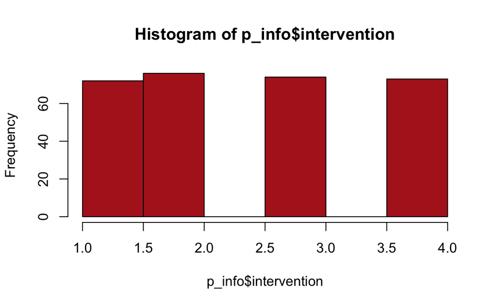

```r
hist(p_info$intervention, col = "firebrick")  # plots a histogram
```

```r
n_i1 <- sum(p_info$intervention == 1)
n_i2 <- sum(p_info$intervention == 2)
n_i3 <- sum(p_info$intervention == 3)
n_i4 <- sum(p_info$intervention == 4)

n_treat <- n_i1 + n_i2 + n_i3
n_treat
```

```
#> [1] 222
```

```r
# Check: All participants NOT in control group 4:
n_treat == (n_total - n_i4)
```

```
#> [1] TRUE
```

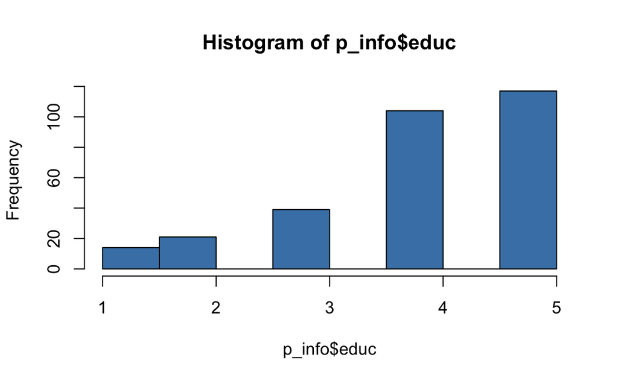

```r
## 4. Education level: -----
hist(p_info$educ, col = "steelblue")
```

```r
mean(p_info$educ)
```

```
#> [1] 3.979661
```

```r
n_educ_uni <- sum(p_info$educ >= 4)

pc_educ_uni <- n_educ_uni/n_total * 100
pc_educ_uni
```

```
#> [1] 74.91525
```

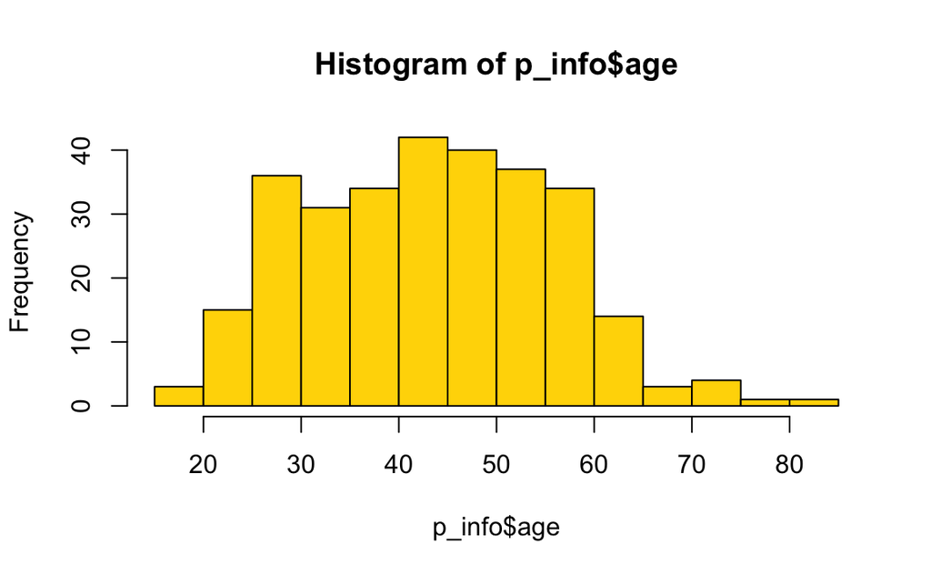

```r
## 5. Age: -----
hist(p_info$age, col = "gold")
```

```r
range(p_info$age)
```

```
#> [1] 18 83
```

```r
mean(p_info$age)
```

```
#> [1] 43.75932
```

```r
median(p_info$age)
```

```
#> [1] 44
```

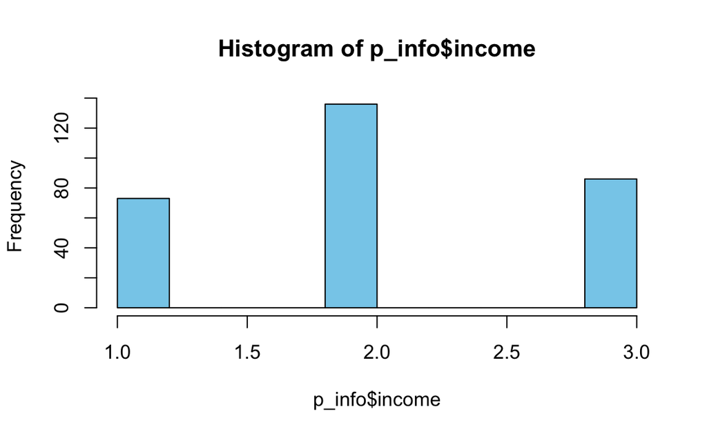

```r
## 6. Income: -----
hist(p_info$income, col = "skyblue")
```

```r
n_income_low <- sum(p_info$income < 2)
pc_income_low <- n_income_low/n_total * 100
pc_income_low
```

```
#> [1] 24.74576
```

**Answers** to **Exercise 6**:

1. The `p_info` data contains 295 individuals.
2. 85.08% of the participants are female.
3. 222 of the participants are in 1 of the 3 treatment groups.
4. 74.92% of the participants have a university degree.
5. Participant’s age values range from 18 to 83 years. Their mean age is 43.76 years, their median age is 44 years.
6. 24.75% of the participants state that their income is below average.

# Related Resources

There is no shortage of introductory R books and scripts, but it’s helpful if you find one that fits your interests and level of expertise.

- An enjoyable introduction to R is [YaRrr! The Pirate’s Guide to R](https://bookdown.org/ndphillips/YaRrr/), an ebook by Nathaniel Phillips that approaches R in a very entertaining fashion.  
  (See [Rpository.com/learnR/](http://rpository.com/learnr/) for corresponding exercises with solutions.)
- For many other materials and scripts, see [R manuals](https://cran.r-project.org/manuals.html) and other documentation.
- For *help* on any R command named `abc`, simply evaluate `?abc` (in the Console or Editor) to show R’s in-built help on the command with this name. For instance, evaluating `?sum` provides a precise definition and some examples of the function `sum` (introduced above). Even when some parts of the definition are difficult to understand at first, it’s typically helpful to examine and run the Examples provided.

# References

The participant data `p_info` (used in **Exercise 6**) is from:

- Woodworth, R. J., O’Brien-Malone, A., Diamond, M. R. and Schüz, B. (2018). Data from, ‘Web-based positive psychology interventions: A reexamination of effectiveness’. *Journal of Open Psychology Data*, *6*: 1. doi: https://doi.org/10.5334/jopd.35

All [ds4psy](http://rpository.com/ds4psy/) essentials so far:

| Nr. | Topic |
| --- | --- |
| 0. | [Syllabus](http://rpository.com/ds4psy/) |
| 1. | **Basic R concepts and commands** |

[Last update on 2019-04-29 19:23:24 by [hn](http://neth.de/).]